# NOAA table

Daniel Kaplan

Many printed tables are meant to be used as functions; you plug in the input values and read off the output. Here’s a table published by the National Oceanic and Atmospheric Administration for the [heat index](https://en.wikipedia.org/wiki/Heat_index), a way of summarizing the perceived comfort (or discomfort) of summer-like weather conditions.

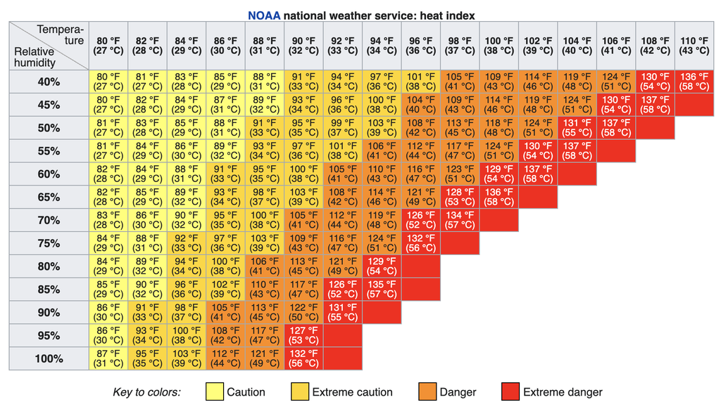

**Question tmp-1**: A) What are the inputs to the heat-index function

1. temperature and relative humidity (+) []
2. temperature and wind speed [Those are the inputs to the wind-chill function, not the heat index.]
3. temperature, latitude, and longitude [The heat index doesn’t depend on location.]

The table actually shows three different functions:

1. The heat index in $^\circ$ F.
2. The heat index in $^\circ$ C.
3. A caution warning level.

**Question tmp-2**: B) For inputs of 70% relative humidity and $88^{\circ}$ F, what are the outputs of the three functions?

1. $100^{\circ}$ F, $38^\circ$ C, and “extreme caution”. (+) []
2. $100^\circ$ F, $38^\circ$ C, and “danger”. [Check again!]
3. $100^\circ$ F, $33^\circ$ C, and “extreme caution”. [33C does is not the same temperature as 100F.]

**Question tmp-3**: C) Holding the relative humidity at 70%, how much would the ambient temperature have to increase (from $88^\circ$ F) to change the caution-level output to “dangerous”?

**Question tmp-4**: D) From a starting point of $88^\circ$ F and 70% humidity, what is the slope of the increase in heat index when moving to 80% humidity.

1. $6^\circ$ F per 10 percentage points humidity (+) []
2. $6^\circ$ F [A slope is always “rise over run”. You’ve got the rise right, but what about the run?]
3. $6^\circ$ F per 80% humidity. [The slope is the change in output divided by the change in input, i.e. “rise over run”. 80% is the humidity at the endpoint, but the run is the change in humidity from the starting point to the endpoint.]

**Question tmp-6**: True or false: The caution-level output could have been presented as a function of just one variable, rather than needing both temperature and humidity both.

1. TRUE (+) [The caution-level output is not a function of ambient temperature alone or of humidity alone. But if you know the heat-index, you know that caution level exactly.]
2. FALSE [Notice that the caution-level output is the same for any given level of the heat index, regardless of the ambient temperature or humidity separately.]

The US National Weather Service also publishes a heat index graphic, the one below.

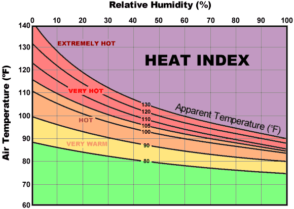

[Source link](https://www.weather.gov/images/oun/wxsafety/summerwx/heatindex.gif)